# A3: SPL Library Checkouts

### Introduction

This data comes from the Seattle Public Library’s current public record of the checkout data of all titles in the 2022-2023 calendar year. I am particularly interested in seeing how particular authors of the past compare to one another in this day and age. To test this I wanted to choose writers who have had a significant effect on generations of children with impact imagery and empathetic storytelling. I have chosen two memorable authors of my childhood to compare the current relevance of Dr. Seuss and Eric Carle. What I seek to determine is the current interest in the books that were my favorite as a kid. To set a bar I will be looking out for the titles “The Very Hungry Catarpillar” by Eric Carle and “The Cat in the Cat” by Dr. Seuss.

### Summary Information

The checkout data from Seattle Public Library’s current record of all titles in the 2022-2023 calendar year was analyzed to compare the current relevance of two memorable children’s authors, Dr. Seuss and Eric Carle. The summary statistics revealed that “The Very Hungry Caterpillar”’s Somali translation, “Duudkii aadka u gaajooday = The very hungry caterpillar / by Eric Carle ; Somali translation by Omar Mohammed., 1” had the least number of checkouts by Eric Carle while his other title, “The very busy spider / by Eric Carle., 393”, had the most checkouts in the data frame. A closer look at Carle’s data would show “The Very Hungry Caterpillar”, comes close to the most popular title with the second-most checkouts. On the other hand, the statistics show that Dr. Seuss’s title’s have an average of 7.5130362 checkouts per title. This is slightly larger than Carle’s average of 6.4040767 checkouts per title. It should also be noted that there are more Seuss (1189) titles than Carle (834) titles. To delve deeper into the scope of these author’s titles/publications I found the oldest title by Eric Carle, “1986, 1972.”, and the publication year(s) (1986, 1972.). In addition I looked into the newest title from the now deceased Dr. Seuss, “Miércoles alocado / Dr. Seuss escrito como Theo. LeSieg ; ilustraciones de George Booth ; traducción de Georgina Lázaro.”, and its publication year ([2020]). None of the most popular books were the ones I guessed from this surface discovery but it was interesting to find that the SPL finds spiders more interesting than hungry caterpillars.

### The Dataset

- This data is collected and published by the Seattle Public Library (SPL), this collection is ongoing.
- There are a total of 12 variables in this dataset: Usage class (i.e. physical, digital), checkout type (i.e. Horizon, OverDrive), material type (i.e. book, audiobook), checkout year, checkout month, checkouts (these three all as integers), title, ISBN rating, creator, subjects (i.e. Health & Fitness, Operas), publisher, and publication year (these rest as plain text).
- SPL gathers information on how its electronic resources—including e-books, databases, and online journals—are used. The library may use this information to assess the value of its digital resources and make wise purchase decisions. SirsiDynix Symphony is an integrated library management system (ILS) that SPL employs to track information about patron registration, item holdings, circulation, and other library activities.
- Understanding SPL users’ borrowing habits is the main goal of gathering this data. Librarians and library administrators can utilize this information to guide decisions about funding, collection development, and other operational tasks. It can also assist academics, writers, and publishers in learning more about Seattle residents’ reading interests and trends.
- There are various ethical issues to think about when using this data. First first, the data could possibly violate readers’ privacy because it includes information about book titles, authors, and genres. Thus, proper steps must be taken to ensure that borrowers’ identity is maintained while this data is being analyzed. Second, because the information is open to the public, discriminatory uses like profiling or focusing on specific communities are possible. So, it is crucial to use this data in an ethical and responsible manner.
- First off, borrowing from other libraries or online sources is not taken into account in the data set; rather, it solely accounts for borrowing within SPL. As a result, it might not accurately reflect the reading habits of Seattle’s total population. The data set’s utility for figuring out the reading preferences of particular populations is also constrained by the absence of demographic data on borrowers. Also, it’s likely that the data may not correctly reflect the borrowing behavior of specific groups, such as people who favor using the physical rather than digital resources available at the library. Second, the collection excludes data on the justifications for borrowing a specific item. As a result, it is impossible for researchers to tell if a book was borrowed for fun, research, or any other reason. It may be difficult to accurately infer reading interests and habits from this restriction. Thirdly, because the data set is in raw format, it might need to be cleaned, filtered, or transformed before it can be studied. This can take a lot of time and may call for specific knowledge and equipment. Finally, there is a chance of privacy infractions, just like with any data set containing personal data. The data set includes data on book authors, genres, and titles, which may betray readers’ interests and violate their privacy. Thus, proper steps must be taken to ensure that borrowers’ identity is maintained while this data is being analyzed.

### First Trends Over Time Chart

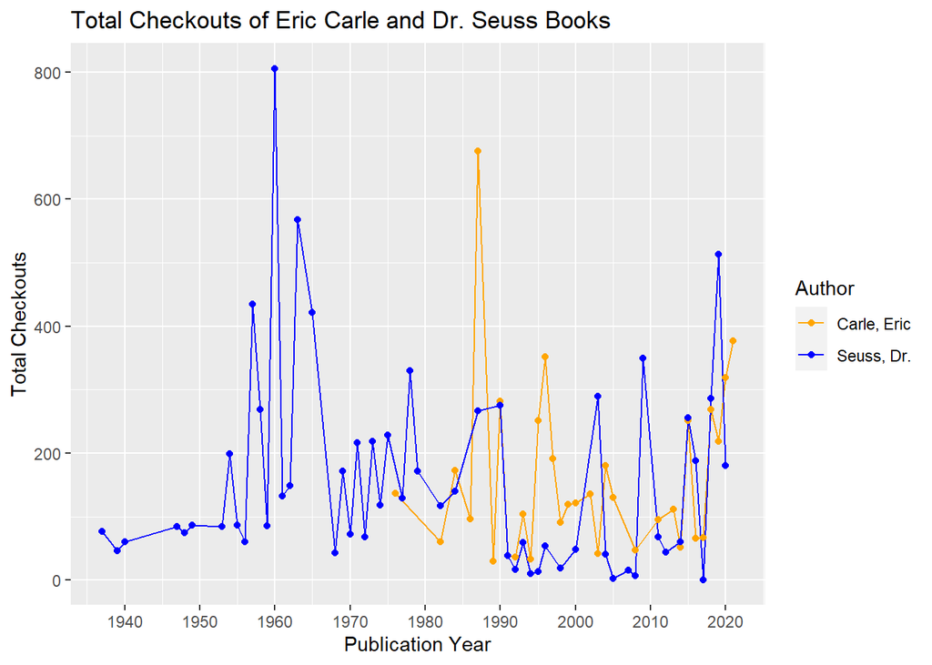

### Second Trends Over Time Chart

I created this chart to visualize the current appeal of some widely-knows books by Dr. Seuss and Eric Carle. For this demonstration, I chose a well-known book (The most widely recognizable) from each of the authors: “The Very Hungry Caterpillar” by Eric Carle and “The Cat in the Hat” by Dr. Seuss. The end product shows an obvious difference in checkouts throughout the year between the two books which opens the doors to many possible inferences. The gap suggests that Dr. Seuss as an author is more well-known than Eric Carle as each of their most popular books show a difference in the level of interest. It pop culture and the author’s history also suggests that Dr. Seuss’s illustrations are highly recognizable and are therefore slightly more desired. It enables quick comparisons between the two authors and draws attention to the difference in their levels of popularity. The graph demonstrates that throughout the year, checkouts for “The Cat in the Hat” by Dr. Seuss were consistently greater than those for “The Very Hungry Caterpillar” by Eric Carle. Overall, the chart offers insightful information about how well-liked these authors’ works are, which could help publishers, librarians, and bookshops plan their marketing campaigns.

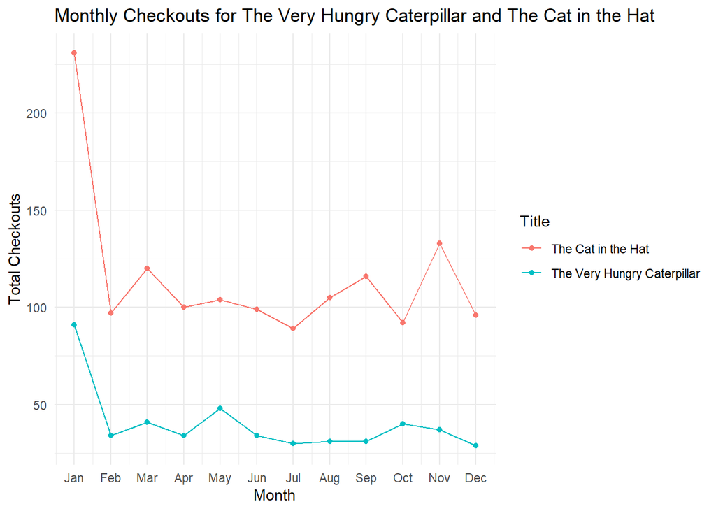

### Your Choice

Visualizing the percentage of checkouts between Eric Carle and Dr. Seuss over the course of the year is a crucial step in understanding the popularity and readership of these authors. The stacked bar chart provides a clear and concise way to compare the two authors’ success over time. By examining the chart, we can see that Carle consistently had fewer checkouts than Dr. Seuss, indicating a difference in popularity between the two. This information can be useful for librarians and booksellers in managing their inventory and determining which titles to promote. They can use this data to stock their shelves with books that are in high demand, while also making sure they have enough copies of the less popular books to meet the needs of their patrons. Moreover, analyzing the percentage of checkouts provides insight into broader reading trends among children and parents. It can help identify popular themes and topics that resonate with readers and provide ideas for future publications. Additionally, it sheds light on how the works of these two authors continue to resonate with audiences today, highlighting their ongoing cultural relevance. This analysis can also inform future publishing decisions, as it offers a better understanding of what readers are looking for in children’s literature.Overall, the stacked bar chart depicting the percentage of checkouts between Eric Carle and Dr. Seuss offers a valuable understanding of the cultural relevance of children’s literature. It not only provides insight into the popularity of these two authors but also broader reading trends and preferences. By examining this data, we can better understand the interests of young readers and make informed decisions about what books to promote and publish in the future.

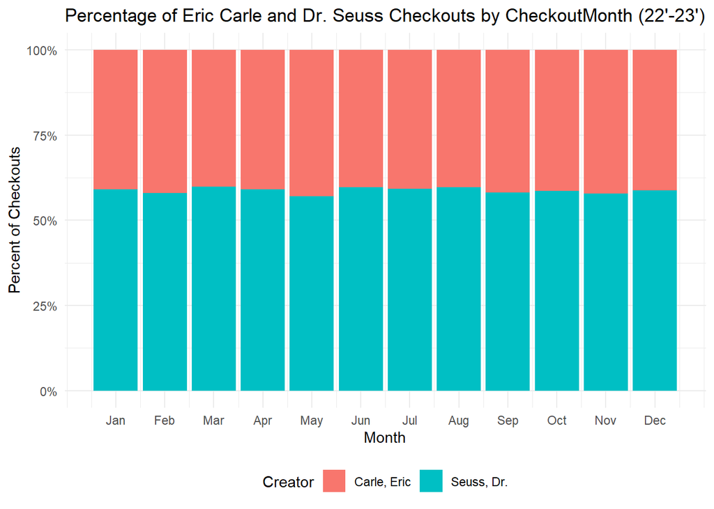